# Compare Old and New Pert Signatures - CCA

```r
knitr::opts_knit$set(root.dir = normalizePath('../../../'))
```

We start by importing the necessary functions

```r
rm(list=ls())
source("RCode/flexible_layers/structureDataFlexible.R")
source("RCode/flexible_layers/sensitivityDataFlexible.R")
source("RCode/flexible_layers/perturbationDataFlexible.R")
source("RCode/flexible_layers/perturbationDataFlexibleCustomSig.R")
source("RCode/flexible_layers/luminexDataFlexible.R")
source("RCode/flexible_layers/imagingDataFlexible.R")
source("RCode/flexible_layers/constSensitivityLayerFlexible.R")
source("RCode/flexible_layers/constStructureLayerFlexible.R")
source("RCode/flexible_layers/constLuminexLayerFlexible.R")
source("RCode/flexible_layers/constImagingLayerFlexible.R")
source("RCode/flexible_layers/constPerturbationLayerFlexible.R")
source("RCode/flexible_layers/integrateLayersFlexible.R")
source("RCode/flexible_layers/generateDrugPairsFlexible.R")
source("RCode/flexible_layers/drugTargetBenchFlexible.R")
source("RCode/flexible_layers/compConcordIndxFlexible.R")
source("RCode/flexible_layers/printCIndices.R")
source("RCode/flexible_layers/printPVals.R")
source("RCode/flexible_layers/generateROCPlotFlexible.R")
source("RCode/flexible_layers/atcBenchFlexible.R")
source("RCode/flexible_layers/compDrugTargetBenchmarkFlexible.R")
source("RCode/flexible_layers/computeATCBenchmarkFlexible.R")
source("RCode/flexible_layers/stackedLayerAnalysisHelpers.R")
source("RCode/flexible_layers/communityGenFlexible.R")
source("RCode/value_inference_models/modifying_snf/snfModifiedHelpers.R")
source("RCode/cindexComp2.R")
source("RCode/predPerf.R")
library(PharmacoGx)
library(apcluster)
library(rcdk)
library(fingerprint)
library(annotate)
library(org.Hs.eg.db)
library(SNFtool)
library(ROCR)
library(survcomp)
library(reshape2)
library(proxy)
library(PRROC)
library(apcluster)
badchars <- "[\xb5]|[\n]|[,]|[;]|[:]|[-]|[+]|[*]|[%]|[$]|[#]|[{]|[}]|[[]|[]]|[|]|[\\^]|[/]|[\\]|[.]|[_]|[ ]"
pert.file.name.old <- "Data/L1000_compound_signatures.RData"
pert.file.name.new <- "Data/pert_sigs_6_hour/pert_cca_correlations.rds"
sensitivity.file.name <- "Data/combined_sensitivity//combined_sens_iname_replaced.RData"
source("RCode/flexible_layers/stackedLayerAnalysis.R")
```

## Load In Data

We start by loading in the lincs metadata file which is used to match senstivity drug names to the l1000 signatures since are indexed according to pert_id instead of pert_iname. It also contains the smiles strings for all the compounds in L1000, and these are used to create the structure layer.

```r
lincs.meta <- read.csv("Data/LINCS.csv", stringsAsFactors = FALSE)
lincs.meta$pert_iname <- toupper(lincs.meta$pert_iname)
lincs.meta$pert_iname <- gsub(badchars, "", lincs.meta$pert_iname)
```

Load in the senstivity and perturbation data. We load in the new perturbation data at this point too since we will need it to subset to common drugs. The issue is that the new perturbation signatures are missing 8 drugs vs the old signatures since they were computed using only 9 cell lines. Thus, we need the drug names from the new signatures to subset the old signatures so that we compare apples with apples.

```r
sens.data <- readRDS(sensitivity.file.name)
pert.data.old <- PerturbationDataFlexible(pert.file.name.old, lincs.meta)
```

[output not shown]

```r
pert.data.new <- PerturbationDataFlexibleCustomSig(pert.file.name.new)
```

Subset the lincs metadata file to only the drugs appearing in the sensitivity layer

```r
sens.names <- rownames(sens.data)
lincs.meta.subset <- lincs.meta[match(sens.names, lincs.meta$pert_iname),]
lincs.meta.subset <- lincs.meta.subset[!is.na(lincs.meta.subset$X),]
```

Now we create the structure fingerprints based on the subsetted lincs metadata

```r
strc.data <- StructureDataFlexible(lincs.meta.subset)  ## a vector  --> 239 elemnts
```

Figure out the drugs common between all 3 layers. Again, the new perturbation layer is most limiting, so we use that instead of the old layer.

```r
layers <- list(sens=rownames(sens.data), pert=colnames(pert.data.new), strc=names(strc.data))
common.drugs <- Reduce(intersect, layers)
```

## Create Similarity Matrices

Computing the similarities (correlations) for the sensitivity layer is slow (have to merge correlations and keep track of how many samples were used to compute each correlation). Also, computing the similarities for the new perturbation signatures is very slow (in the case of using RV coefficient). Due to the two previously mentioned sentences, `sens.data` is actually a similarity matrix, and `pert.data.new` is also a similarity matrix, not a feature matrix.

Thus, the only similarity matrices we need to create are for the old perturbation signatures, and the structure layer.

```r
sens.cor <- sens.data[common.drugs, common.drugs]
pert.cor.old <- cor(pert.data.old[, common.drugs], method="pearson", use="pairwise.complete.obs")
pert.cor.new <- pert.data.new[common.drugs, common.drugs]
strc.cor <- fingerprint::fp.sim.matrix(strc.data[common.drugs], method = "tanimoto")
rownames(strc.cor) <- names(strc.data[common.drugs])
colnames(strc.cor) <- names(strc.data[common.drugs])
```

## Performance Evalution

### Old Signatures

Now we need to take the previous similarity matrices, convert them into affinity matrices and fuse them using SNF

```r
correlation.matrices <- list(sens=sens.cor, pert=pert.cor.old, strc=strc.cor)

affinity.matrices <- CreateAffinityMatrices(correlation.matrices)
integrated <- SNFtool::SNF(affinity.matrices)
rownames(integrated) <- common.drugs
colnames(integrated) <- common.drugs
```

#### CTRPv2 Benchmark

```
[1] "Benchmark obtained"
[1] "Drug pairs obtained"
[1] "Concordance Index computed"
c.indices values from each layer vs. the benchmark:
strcCindex: 0.701266
sensCindex: 0.8856304
pertCindex: 0.641241
integrCindex: 0.9195476
p-vals from the c.index comparison of integration layer vs.
strcPVal: 6.431443e-54
sensPVal: 0.001059588
pertPVal: 7.543861e-68
png
  2
```

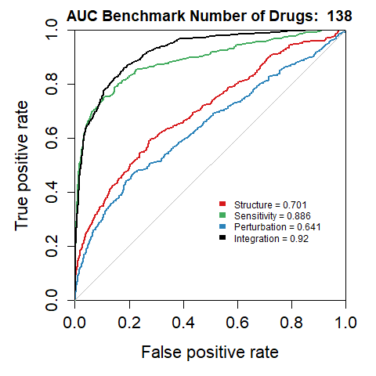

```r
CompDrugTargetBenchmarkFlexible(common.drugs, "temp", affinity.matrices$strc,
                                    affinity.matrices$sens, affinity.matrices$pert, integrated, NULL, NULL,
                                    "target.roc.file.name", use.ctrpv2=T,
                                    use.clue=F, use.chembl=F, use.dbank=F, use.dtc=F)
```

```
[1] "Benchmark obtained"
[1] "Drug pairs obtained"
[1] "Concordance Index computed"
c.indices values from each layer vs. the benchmark:
strcCindex: 0.6819449
sensCindex: 0.7168191
pertCindex: 0.6070123
integrCindex: 0.810102
p-vals from the c.index comparison of integration layer vs.
strcPVal: 5.400781e-49
sensPVal: 8.963977e-20
pertPVal: 9.890545e-94
png
  2
```

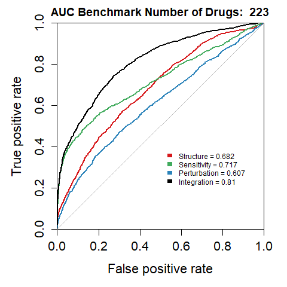

```r
CompDrugTargetBenchmarkFlexible(common.drugs, "temp", affinity.matrices$strc,
                                    affinity.matrices$sens, affinity.matrices$pert, integrated, NULL, NULL,
                                    "target.roc.file.name", use.ctrpv2=T,
                                    use.clue=T, use.chembl=T, use.dbank=T, use.dtc=F)
```

### New Signatures

Now we need to take the previous similarity matrices, convert them into affinity matrices and fuse them using SNF

```r
correlation.matrices <- list(sens=sens.cor, pert=pert.cor.new, strc=strc.cor)

affinity.matrices <- CreateAffinityMatrices(correlation.matrices)
integrated <- SNFtool::SNF(affinity.matrices)
rownames(integrated) <- common.drugs
colnames(integrated) <- common.drugs
```

#### CTRPv2 Benchmark

```
[1] "Benchmark obtained"
[1] "Drug pairs obtained"
[1] "Concordance Index computed"
c.indices values from each layer vs. the benchmark:
strcCindex: 0.701266
sensCindex: 0.8856304
pertCindex: 0.6738144
integrCindex: 0.9343306
p-vals from the c.index comparison of integration layer vs.
strcPVal: 1.17131e-59
sensPVal: 2.314113e-06
pertPVal: 7.55905e-61
png
  2
```

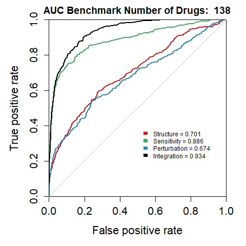

```r
CompDrugTargetBenchmarkFlexible(common.drugs, "temp", affinity.matrices$strc,
                                    affinity.matrices$sens, affinity.matrices$pert, integrated, NULL, NULL,
                                    "target.roc.file.name", use.ctrpv2=T,
                                    use.clue=F, use.chembl=F, use.dbank=F, use.dtc=F)
```

#### Combined CTRPv2. CLUE, CHEMBL Benchmark

```
[1] "Benchmark obtained"
[1] "Drug pairs obtained"
[1] "Concordance Index computed"
c.indices values from each layer vs. the benchmark:
strcCindex: 0.6884201
sensCindex: 0.7233891
pertCindex: 0.6160463
integrCindex: 0.8391244
p-vals from the c.index comparison of integration layer vs.
strcPVal: 3.663444e-64
sensPVal: 2.145897e-29
pertPVal: 1.39916e-96
png
  2
```

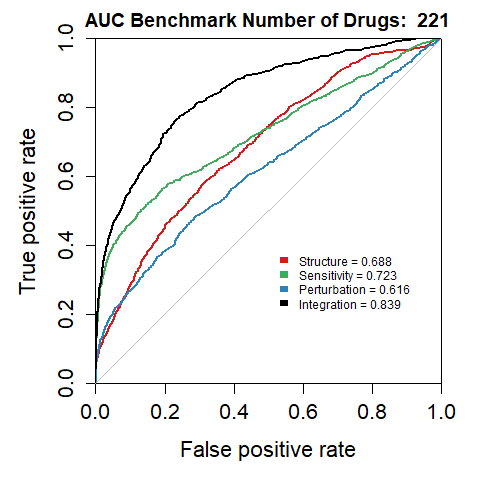

```r
CompDrugTargetBenchmarkFlexible(common.drugs, "temp", affinity.matrices$strc,
                                    affinity.matrices$sens, affinity.matrices$pert, integrated, NULL, NULL,
                                    "target.roc.file.name", use.ctrpv2=T,
                                    use.clue=T, use.chembl=T, use.dbank=F, use.dtc=F)
```